# eMOLT Update

*eMOLT Update 2025-10-01*

## Weekly Recap

This week’s update is coming a little early, because I am not sure whether I will be able to put one together on Friday. As of today, October 1, the government is shut down and I am furloughed. For the duration of the shutdown, I will be unavailable by phone or email. For immediate tech support, please contact your local tech.

- Downeast and Mid-Coast Maine: Andrew Goode (UMaine), Emma Weed (GOMLF), or Erin Pelletier (GOMLF)
- S. Maine, New Hampshire, and North Shore Mass: Erin Pelletier (GOMLF) or Jack Carroll (Ocean Data Network)
- South Shore Mass: Huanxin Xu (GOMLF) or Samir Patel (Coonamessett Farm Foundation)
- Cape Cod and the Islands: Huanxin Xu (GOMLF) or Owen Nichols (Center for Coastal Studies)
- South Coast Mass: Huanxin Xu (GOMLF) or Cassie Tillotson (Coonamessett Farm Foundation)
- Rhode Island and Connecticut: Linus Stoltz (CFRF) or Huanxin Xu (GOMLF)
- New Jersey: Joey O’Brien (Rutgers)

For questions about the MassTech Project such as requesting a system or checking on the status of a vessel stipend, please contact Melissa at the Cape Cod Commercial Fishermen’s Alliance (508-945-2432).

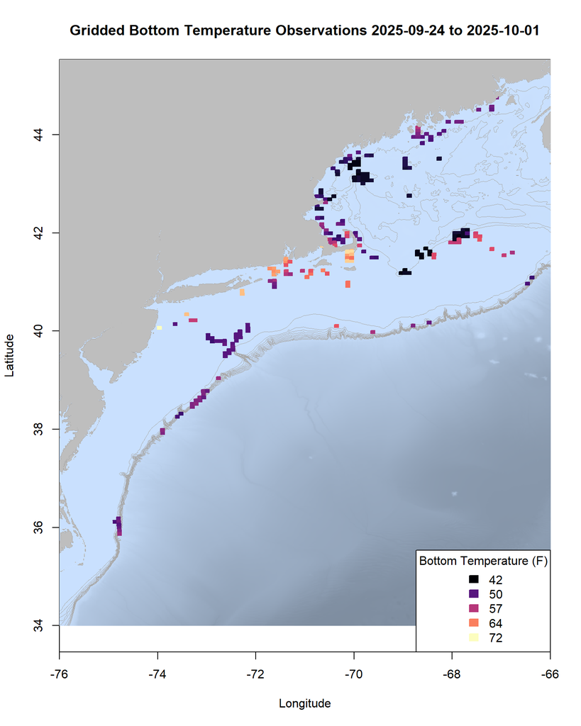

> *Figure 1 – FISHBOT bottom temperature records from the past week. The data are available on the [Commercial Fisheries Research Foundation ERDDAP](https://erddap.ondeckdata.com/erddap/tabledap/fishbot_realtime.html) and an interactive visualization is available at the [Cape Cod Ocean Watch](https://ccocean.whoi.edu/index.html) dashboard hosted by Woods Hole Oceanographic Institution. FISHBOT aggregates data provided by participants in eMOLT, the CFRF Lobster and Jonah Crab Research Fleet, the CFRF Shelf Research Fleet, the Cape Cod Commercial Fishermen’s Alliance Cape Cod Oceanographic Research Fleet, the Maine Coast Fishermen’s Association Fisheries Ocean Data Program, MassDMF Cape Cod Bay Study Fleet, the Northeast Fisheries Science Center Study Fleet, and the Northeast Fisheries Science Center Ecosystem Monitoring Surveys*

### Regional Dissolved Oxygen Loggers

Dissolved oxygen loggers just south of Jamestown Rhode Island,south of Cape Cod, and along the Maine coast reported normal values.

### [Dissolved Oxygen in Cape Cod Bay](https://experience.arcgis.com/experience/0d553dfc6c60487cb1f4d20b5366ee0b/page/Map-Page/)

This week, there were several low readings in the southwestern part of Cape Cod Bay although none of those readings were below the 2 mg/l hypoxia threshold. North and west of the canal entrance lighted bell buoy oxygen levels still look good. West of Wellfleet, oxygen readings were “Very Low” (2-4 mg/l). You can click on the link above to access MassDMF’s interactive data display online.

[figure not shown]

> *Figure 2 – Dissolved oxygen observations from Cape Cod Bay collected by participants in the eMOLT program and the Cape Cod Bay Study Fleet program operated by Massachusetts Division of Marine Fisheries and the Massachusetts Lobstermen’s Association over the past week. Purple dots indicate dissolved oxygen values in the normal range (> 6 mg/L), yellow dots indicate low dissolved oxygen values (4-6 mg/L), orange dots indicate very low dissolved oxygen values (2-4 mg/L), and red dots indicate critically low values (< 2 mg/L).*

### Registration is open for the Northeast Cooperative Research Summit

[Registration](https://docs.google.com/forms/d/e/1FAIpQLSdEOiWo43NhsRpQHYecVgd6nBpvPHVAzztcH8XC2iXBKmKvyA/viewform) for the 2026 [Northeast Cooperative Research Summit](https://www.fisheries.noaa.gov/event/2026-northeast-cooperative-research-summit) on February 26, 2026 in Riverhead, New York is live! Everyone involved or interested in cooperative research is encouraged to attend, participate in breakout discussions and the research prioritization exercise, or contribute a presentation. Registration is open until November 7, 2025. Participation stipends are available for the first 30 on-the-water fishermen that register.

### New England Fishery Management Council Seeks Applicants for Advisory Panels

The New England Fishery Management Council is seeking commercial and recreational fishermen and stakeholders to serve on all its advisory panels. The deadline to apply is October 3, 2025.

To apply, please complete this application and email it to Sherie Goutier sgoutier@nefmc.org or mail it to New England Fishery Management Council, 50 Water Street, Mill 2, Newburyport, MA 01950.

### [NOAA Fisheries Seeks Recommendations for Restoring American Seafood Competitiveness](https://www.fisheries.noaa.gov/feature-story/noaa-fisheries-seeks-recommendations-restoring-american-seafood-competitiveness)

A 45-day public comment period in support of [Executive Order 14276 (Restoring American Seafood Competitiveness)](https://www.whitehouse.gov/presidential-actions/2025/04/restoring-american-seafood-competitiveness/) is open until October 14, 2025. To read more about the comment period, click the links above. For instructions on how to comment, check out the Federal Register [here](https://www.federalregister.gov/documents/2025/08/27/2025-16377/recommendations-for-restoring-american-seafood-competitiveness#addresses)

### NERACOOS Seeks Fishing Industry Input

The NERACOOS Mariners’ Dashboard provides real-time weather and ocean info to help plan your time on the water, and they need your help to make it even better. Please take a few minutes to let them know what works, what doesn’t, and what would make the Dashboard more useful for you by [filling out the short survey here](https://www.surveymonkey.com/r/V5F5Z7P)

### Disclaimer

The eMOLT Update is NOT an official NOAA document. Mention of products or manufacturers does not constitute an endorsement by NOAA or Department of Commerce. The content of this update reflects only the personal views of the authors and does not necessarily represent the views of NOAA Fisheries, the Department of Commerce, or the United States.

All the best,

-George